# Generalised Linear Models 4: Poisson and other count models, and choosing variables

Dr. Eugenie Hunsicker

Copyright Loughborough University, 2021 Last update: 22 November

# Preamble

```r
library("tidyverse")
library("magrittr")
library("here")
library("janitor")
library("readxl")
library("AmesHousing")
```

```r
library("rcompanion")
library("ggcorrplot")
library("corrr")
playerstats <- clean_names(read_csv(here("data", "england-premier-league-players-2018-to-2019-stats.csv"),
                            na = c("?","","NA","N/A","Na"),))
ames<-make_ames()
```

# Section 7: Poisson models

Poisson models are used when the response variable of interest is a count variable (no chihuahas, 1 chihuahua, 2 chihuahuas, 3 chihuahuas, etc). Even though counts are numbers, we can’t model them using a Gaussian model because a count can’t be a fraction, just a whole number. So we need to use a distribution that will only predict whole number values (a *discrete distribution*). Note that although the predictions have to be whole numbers, the expected value $E(X)$ for a Poisson variable $X$ *can* be a fraction, just as the average of a set of whole numbers can be.

A second thing about counts is that they have to be > 0. You can’t have -1 chihuahua. So if $X$ is a Poisson variable, then $E(X)>0$ as well. This means we need a link function that takes the positive numbers to the set of all numbers, so that it can map to the set of numbers that can arise on the right (linear) side of the glm equation. This is why we use the link g=log, since log takes any positive number as input, and its responses can be any real number.

So the general form of a Poisson model is:
$$\log(E(X)) = b_0 + b_1y_1+ \cdots + b_ky_k.$$

Poisson distributions have just one parameter, so we can also write:
$$X \sim {\rm Pois}(\exp(b_0 + b_1y_1+ \cdots + b_ky_k))$$

## 7.1: Aside

You may notice here that the variables we have considered as response variables for the Gaussian models above, like Diameter and Volume, *also* have to be positive numbers, so their expected values should also always be positive, unlike the right hand sides of the model equations, which in principle could be negative. And yet, we used a constant link function, so it doesn’t make these two sides compatible.

This is a good observation, and relates to a subtle point. This is that *models are only really valid around the values of the variables that were used to create them*. So for the trees, for instance, where we are predicting Diameter from Height, the minimal height measured was 63 feet and the maximal height was 87. So we only really expect our model to work well in that range, or maybe just slightly outside it.

If we go back to the first model we constructed:
$$E(X) =-6.1884 + 0.255\times {\rm Height},$$

we can see that for heights of less than about 24 feet, the average predicted Diameter is negative, which of course doesn’t make sense. What this tells us is that our model certainly breaks down before we get that far below the 63 minimum height on which the model was based.

It shouldn’t surprise us that models are only useful for certain ranges of values–think of gravity. As long as we are talking about any relatively small object (a basketball, a teacup) being attracted to a fixed large object (Earth) we can think of this as gravity as giving a constant acceleration of -9.8 m/s^2. But this model wouldn’t work if we were on another planet–the constant would be different. And if we are talking about two very large objects, like the Sun and the various planets, rather than one large object and various small ones (a basketball) then the model isn’t constant at all, but instead also depends upon the distance between the two objects.

## 7.2: Some count data

We can have a look at it:

```r
playerstats
```

```
## # A tibble: 572 x 46
##    full_name   age birthday league season position current_club minutes_played_~
##    <chr>     <dbl>    <dbl> <chr>  <chr>  <chr>    <chr>                   <dbl>
##  1 Aaron Cr~    30   6.30e8 Premi~ 2018/~ Defender West Ham Un~             1589
##  2 Aaron Le~    33   5.46e8 Premi~ 2018/~ Midfiel~ Burnley                  1217
##  3 Aaron Mo~    29   6.53e8 Premi~ 2018/~ Midfiel~ Huddersfiel~             2327
##  4 Aaron Ra~    29   6.62e8 Premi~ 2018/~ Midfiel~ Arsenal                  1327
##  5 Aaron Ro~    19   9.68e8 Premi~ 2018/~ Forward  Huddersfiel~               69
##  6 Aaron Wa~    22   8.81e8 Premi~ 2018/~ Midfiel~ Crystal Pal~             3135
##  7 Abdelham~    23   8.49e8 Premi~ 2018/~ Midfiel~ Huddersfiel~               49
##  8 Abdoulay~    27   7.26e8 Premi~ 2018/~ Midfiel~ Watford                  3062
##  9 Aboubaka~    25   7.95e8 Premi~ 2018/~ Forward  Fulham                    687
## 10 Adalbert~    23   8.65e8 Premi~ 2018/~ Forward  Watford                     0
## # ... with 562 more rows, and 38 more variables: minutes_played_home <dbl>,
## #   minutes_played_away <dbl>, nationality <chr>, appearances_overall <dbl>,
## #   appearances_home <dbl>, appearances_away <dbl>, goals_overall <dbl>,
## #   goals_home <dbl>, goals_away <dbl>, assists_overall <dbl>,
## #   assists_home <dbl>, assists_away <dbl>, penalty_goals <dbl>,
## #   penalty_misses <dbl>, clean_sheets_overall <dbl>, clean_sheets_home <dbl>,
## #   clean_sheets_away <dbl>, conceded_overall <dbl>, conceded_home <dbl>, ...
```

The variable “goals_overall” is a good example of a count variable. We can imagine creating a model for goals_overall depending on the continuous predictor, “minutes_played_overall” and the categorical predictor, “position”.

First let’s have a look at some plots.

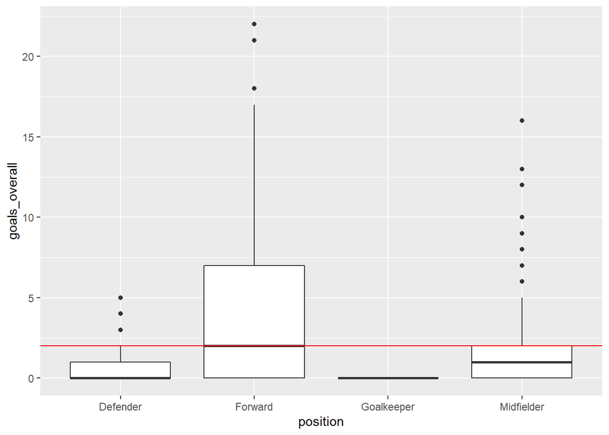

```r
playerstats %>% ggplot(aes(position, goals_overall))+
  geom_boxplot()+
  geom_hline(yintercept=2,col="red")
```

You can notice for each position with the exception of Goalkeeper, the bulk of the data is near zero, with even half of forwards scoring 2 or fewer goals (red line). On the other hand, some players (the dots), score many more. This is typical of Poisson distributed variables–they are often clustered near zero with long “tails” into higher numbers. We can also look at the goals for Forwards as a histogram:

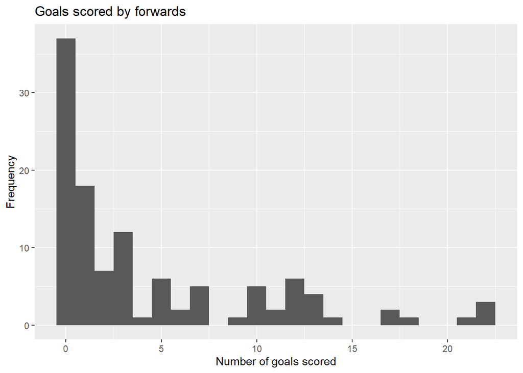

```r
playerstats %>% filter(position=="Forward")  %>%
  ggplot(aes(goals_overall))+
  geom_histogram(binwidth = 1)+
  labs(x="Number of goals scored",y="Frequency",title="Goals scored by forwards")
```

Now look at goals scored versus minutes played for each position:

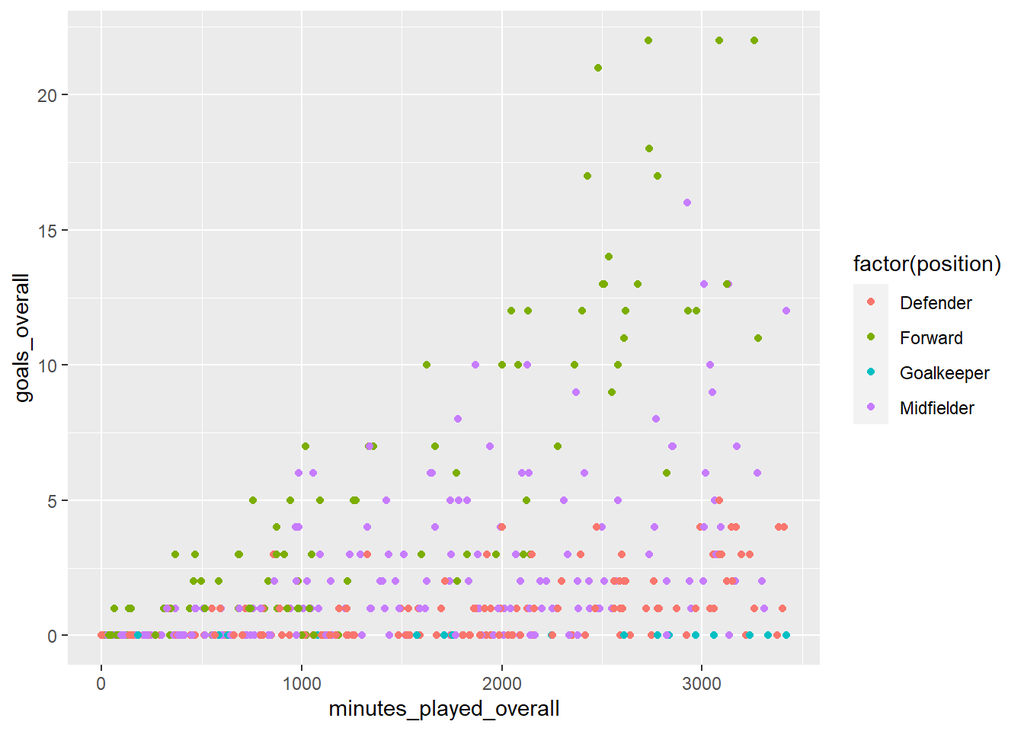

```r
playerstats %>% ggplot(aes(x=minutes_played_overall,y=goals_overall,colour = factor(position)))+
  geom_point()
```

We can that for each group other than goalkeepers, as minutes played increases, the spread gets further and further up the number of goals. Unlike with Gaussian models, we *do not* expect the spread to be constant in the predictor, because in Poisson distributions, variance=mean, and we expect these both to depend on the (continuous) predictor. Instead, we will have to examine the variance=mean assumption for our data later, and if not, consider how to deal with *overdispersion* or possibly *underdispersion*.

## 7.3: Fitting a Poisson model

To fit a Poisson model, we use basically the same command as before, but with family=“poisson”. As with the glm command for logistic regression, the program knows automatically to use a log link.

```r
poissonmod<-glm(goals_overall~minutes_played_overall+position,data=playerstats,family="poisson")
summary(poissonmod)
```

```
##
## Call:
## glm(formula = goals_overall ~ minutes_played_overall + position,
##     family = "poisson", data = playerstats)
##
## Deviance Residuals:
##     Min       1Q   Median       3Q      Max
## -4.1790  -0.9660  -0.4552   0.3159   4.0960
##
## Coefficients:
##                          Estimate Std. Error z value Pr(>|z|)
## (Intercept)            -2.288e+00  1.207e-01 -18.960   <2e-16 ***
## minutes_played_overall  9.726e-04  3.424e-05  28.409   <2e-16 ***
## positionForward         2.182e+00  9.776e-02  22.324   <2e-16 ***
## positionGoalkeeper     -1.747e+01  5.511e+02  -0.032    0.975
## positionMidfielder      1.128e+00  9.997e-02  11.286   <2e-16 ***
## ---
## Signif. codes:  0 '***' 0.001 '**' 0.01 '*' 0.05 '.' 0.1 ' ' 1
##
## (Dispersion parameter for poisson family taken to be 1)
##
##     Null deviance: 2502.88  on 571  degrees of freedom
## Residual deviance:  845.94  on 567  degrees of freedom
## AIC: 1615.6
##
## Number of Fisher Scoring iterations: 16
```

## 7.4: Evaluating the dispersion assumption

We would like to see if the assumption that variance=mean is reasonable for this dataset. To do this we will create a plot of the absolute value of residuals versus predicted means, which should look flat, and hover around 0.8 (the green line). Note that the ggplot version of the diagnostic plots only works for Gaussian family, so instead we use the following:

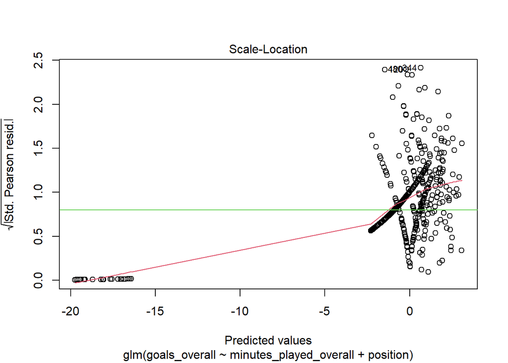

```r
plot(poissonmod,which=3)
abline(h=0.8,col=3)
```

This plot (the red line) definitely isn’t flat, but it seems we may be running into trouble due to the goalkeepers, who are really not relevant to goal scoring activity. So let’s build a new model without them.

```r
poissonmod2<-glm(goals_overall~minutes_played_overall+position,data=playerstats[!playerstats$position=="Goalkeeper",],family="poisson")
summary(poissonmod2)
```

```
##
## Call:
## glm(formula = goals_overall ~ minutes_played_overall + position,
##     family = "poisson", data = playerstats[!playerstats$position ==
##         "Goalkeeper", ])
##
## Deviance Residuals:
##     Min       1Q   Median       3Q      Max
## -4.1790  -1.0547  -0.5978   0.4479   4.0960
##
## Coefficients:
##                          Estimate Std. Error z value Pr(>|z|)
## (Intercept)            -2.288e+00  1.207e-01  -18.96   <2e-16 ***
## minutes_played_overall  9.726e-04  3.424e-05   28.41   <2e-16 ***
## positionForward         2.182e+00  9.776e-02   22.32   <2e-16 ***
## positionMidfielder      1.128e+00  9.997e-02   11.29   <2e-16 ***
## ---
## Signif. codes:  0 '***' 0.001 '**' 0.01 '*' 0.05 '.' 0.1 ' ' 1
##
## (Dispersion parameter for poisson family taken to be 1)
##
##     Null deviance: 2284.54  on 514  degrees of freedom
## Residual deviance:  845.94  on 511  degrees of freedom
## AIC: 1613.6
##
## Number of Fisher Scoring iterations: 5
```

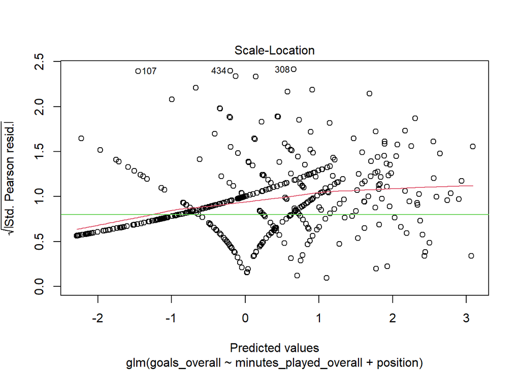

```r
plot(poissonmod2,which=3)
abline(h=0.8,col=3)
```

This certainly looks better, but the red line is still not flat, and it rises above 0.8. This suggests a slight *overdispersion* in the data that increases linearly as the prediction increases. If the red line were under the green one, it would be *underdispersed*. Overdispersion is pretty common when we have not accounted for all of the important predictors in our model. In this case, the overdispersion isn’t too bad, but we may still want to tweak our results.

## 7.5: Other count models

Another possibility if the dispersion assumption is not satisfied is to fit a different model for counts in which the variance (dispersion) is not assumed to be the same as the mean. So this is a model with a hidden dispersion parameter that can be used for overdispersed count data. There are two standard models that do this. *Quasipoisson* models assume that the dispersion is a *linear* function of the mean, so this would be appropriate for our model above, while *Negative Binomial* models assume that dispersion is a *quadratic* function of the mean, so if the red line looked more like an upward parabola. For underdispersed data, where the red line lies below the green line, a *generalised Poisson* model may be used.

There are often mechanisms at work in count data that mean that a none of these four models is appropriate. These include for example:

1. The dataset consists of members of two groups, and only one of those groups can achieve a nonzero count. For example, imagine a set of visitors to Blackpool Pleasure Beach amusement park. We could ask visitors all to record how many times they went on “The Big One” roller coaster. This roller coaster has a height limit of 1.32 meters. So anyone responding who is under that height will automatically have zero rides, whereas individuals above that height limit may have zero or a positive number of rides. This is called *zero inflation*.
2. The dataset consists of members of two groups, one of which group all have a zero count and the other group all have nonzero counts. For example, imagine a set of customers at a grocery store. For each one, we count the number of apples purchased. In reality, there are customers who have purchased apples (some) and those who have not (most). Among those who have, they may have purchased any *positive* number of apples. This is called a *hurdle model*.
3. Having a nonzero response for the count data is a condition for inclusion in the dataset. For example, a study about patients in an obstetrics ward may look at the number of pregnancies an individual has had. However, only individuals who have had at least one pregnancy will be seen on an obstetrics ward, thus number of pregnancies on this population will be zero truncated.

Fitting a quasiPoisson model is pretty straightforward:

```r
poissonmod3<-glm(goals_overall~minutes_played_overall+position,
                 data=playerstats[!playerstats$position=="Goalkeeper",],family="quasipoisson")
summary(poissonmod3)
```

```
##
## Call:
## glm(formula = goals_overall ~ minutes_played_overall + position,
##     family = "quasipoisson", data = playerstats[!playerstats$position ==
##         "Goalkeeper", ])
##
## Deviance Residuals:
##     Min       1Q   Median       3Q      Max
## -4.1790  -1.0547  -0.5978   0.4479   4.0960
##
## Coefficients:
##                          Estimate Std. Error t value Pr(>|t|)
## (Intercept)            -2.288e+00  1.621e-01 -14.110  < 2e-16 ***
## minutes_played_overall  9.726e-04  4.601e-05  21.141  < 2e-16 ***
## positionForward         2.182e+00  1.314e-01  16.612  < 2e-16 ***
## positionMidfielder      1.128e+00  1.343e-01   8.399 4.47e-16 ***
## ---
## Signif. codes:  0 '***' 0.001 '**' 0.01 '*' 0.05 '.' 0.1 ' ' 1
##
## (Dispersion parameter for quasipoisson family taken to be 1.80585)
##
##     Null deviance: 2284.54  on 514  degrees of freedom
## Residual deviance:  845.94  on 511  degrees of freedom
## AIC: NA
##
## Number of Fisher Scoring iterations: 5
```

Note that the estimated dispersion parameter, 1.80585, is indeed greater than 1, confirming mild overdispersion. Note also that the model coefficients are the same as for the Poisson model–only the dispersion estimate has changed.

We will not cover the other types of model here, but it is useful to be aware of them when considering count data.

# Section 8: Considerations when deciding right side of model

## 8.1: Dimensionality

When we build a glm (or an lm), we have a certain number of coefficients, or parameters, that appear in the equation, and these are estimated in the “model fitting” procedure we use when we use the glm or lm commands.

$$g(E(X;y))= b_0 + b_1x_1 + ... + b_nx_n$$
Here, there are $n+1$ parameters to estimate. General rule of thumb: we need at least 15 cases in our data for each parameter in order even to obtain stable estimates of the parameters. If you have fewer than this, you will expect the parameter estimates to vary dramatically as your sample varies.

So, before you start out even thinking about your model, it is useful to estimate how many parameters you can “afford” in your final model.

- One parameter is automatic as the $b_0$
- Each covariate (numerical predictor) yields a single parameter.
- Each factor yields (k-1) parameters, where k=number of levels.
- If you include interactions, you have to add additional parameters for the interaction terms.

Additionally, if your response variable is a factor, you need not only 15 cases, but 15 cases PER GROUP in the response.

So, for example, in the AmesHousing dataset, if we want a model of sale price, and we put all of the variables into the model, we would have:

```r
1 + 15 + 6 + 1 +1 +1+2+3+3+2+4+2+28+8+4+7+9+9+1+1+5+7+15+16+4+1+3+4+5+5+5+4+6+1+6+1+1+1+5+4+1+5+1+1+1+1+1+1+1+1+1+1+4+1+7+1+5+6+3+1+1+5+5+2+1+1+1+1+1+1+4+4+5+1+1+1+9+5+1+1
```

```
## [1] 302
```

302 parameters to estimate. So we would need at least

```r
302*15
```

```
## [1] 4530
```

cases in order to fit the model. So we don’t have enough. The largest model we might possibly be able to build would have

```r
2930/15
```

```
## [1] 195.3333
```

About 195 parameters. If we want to have smaller confidence intervals for our results, we would want many fewer parameters. (The more cases/parameter, the smaller the confidence intervals become).

This is why amongst “large data” sets, those which are wide (lots of parameters) and short (not many cases) are the most problematic. To work with such datasets, we need ways to reduce dimensions (ie, eliminate some variable or parameters in our model).

The rest of this module will be spent learning ways to reduce the dimensions in wide, short datasets.

## 8.2: Missingness

If there are variables for which a reasonably large set of cases are missing, remove them. How many cases missing is too many? You will not be surprised to hear this depends.

The most important thing to ask is: how important is that particular variable to the question you are trying to answer? Eg, if you want to understand the effect of walking at least 10000 steps/day on blood pressure, but you recognise that to understand this, you need to control for several other things, e.g., biological sex, weight, age, etc. If number of steps per day is missing even for half of the cases, you still need to use it. You just only have half the data you thought.

** You can’t remove a variable that is central to your investigation **

The most conservative way to do this is to rank variables in terms of missingness, from least missing to most missing. Then see how many complete cases there are in your data when you include more and more variables with missing data. Choose some threshold that will give you a reasonable number of complete cases for “most of” the variables of interest.

It turns out that there are other ways (which we won’t talk about in this module) to handle missing data other than just using complete cases (imputation). And in that case, you need to make a judgement.

Rule of thumb: None of the variables should be missing more than a quarter of cases, and most should be missing no more than 10%.

But in this module, we’ll use the conservative way because we don’t know imputation.

The two issues with just removing incomplete cases are 1) results in few cases 2) Sometimes missingness is “informative”

Eg, suppose you have a dataset with a variable that is “days to recovery from coronavirus”. There will be cases where this is missing, because people haven’t yet recovered (“long covid” cases). If we remove cases where “days to recovery” is missing, we are preferentially removing cases corresponding to individuals for whom the illness has lasted a long time. So doing this will cause us to underestimate the average length of infection from covid. Even if length of illness wasn’t the target response, it may still be important for the other variables. Eg, suppose target was number of days in ICU, and all patients had left ICU, removing long covid cases would skew your results. In that case, you might be better off removing the variable than the cases.

## 8.3: Correlations among predictors

When predictor variables are strongly correlated, they will carry similar information about the response. So we can eliminate one of a pair of strongly correlated variables without losing too much information.

```r
mixed_assoc = function(df, cor_method="spearman", adjust_cramersv_bias=TRUE){
    df_comb = expand.grid(names(df), names(df),  stringsAsFactors = F) %>% rlang::set_names("X1", "X2")

    is_nominal = function(x) class(x) %in% c("factor", "character")
    # https://community.rstudio.com/t/why-is-purr-is-numeric-deprecated/3559
    # https://github.com/r-lib/rlang/issues/781
    is_numeric <- function(x) { is.integer(x) || is_double(x)}

    f = function(xName,yName) {
        x =  pull(df, xName)
        y =  pull(df, yName)

        result = if(is_nominal(x) && is_nominal(y)){
            # use bias corrected cramersV as described in https://rdrr.io/cran/rcompanion/man/cramerV.html
            cv = cramerV(as.character(x), as.character(y), bias.correct = adjust_cramersv_bias)
            data.frame(xName, yName, assoc=cv, type="cramersV")

        }else if(is_numeric(x) && is_numeric(y)){
            correlation = cor(x, y, method=cor_method, use="complete.obs")
            data.frame(xName, yName, assoc=correlation, type="correlation")

        }else if(is_numeric(x) && is_nominal(y)){
            # from https://stats.stackexchange.com/questions/119835/correlation-between-a-nominal-iv-and-a-continuous-dv-variable/124618#124618
            r_squared = summary(lm(x ~ y))$r.squared
            data.frame(xName, yName, assoc=sqrt(r_squared), type="anova")

        }else if(is_nominal(x) && is_numeric(y)){
            r_squared = summary(lm(y ~x))$r.squared
            data.frame(xName, yName, assoc=sqrt(r_squared), type="anova")

        }else {
            warning(paste("unmatched column type combination: ", class(x), class(y)))
        }

        # finally add complete obs number and ratio to table
        result %>% mutate(complete_obs_pairs=sum(!is.na(x) & !is.na(y)), complete_obs_ratio=complete_obs_pairs/length(x)) %>% rename(x=xName, y=yName)
    }

    # apply function to each variable combination
    map2_df(df_comb$X1, df_comb$X2, f)
}
```

```r
varassoc<-mixed_assoc(ames)
varassoc
```

[output not shown]

[output cut: 13069 more lines]

[output not shown]

```r
varassoc[varassoc$assoc>0.8 & !(varassoc$x==varassoc$y),]
```

```
##                              x              y     assoc        type
## Cramer V...15        Bldg_Type    MS_SubClass 0.8883000    cramersV
## Cramer V...16      House_Style    MS_SubClass 0.8296000    cramersV
## ...19               Year_Built    MS_SubClass 0.8105946       anova
## ...44            Second_Flr_SF    MS_SubClass 0.8907814       anova
## ...52            Kitchen_AbvGr    MS_SubClass 0.8157711       anova
## ...910              Year_Built   Neighborhood 0.8838408       anova
## ...971               Longitude   Neighborhood 0.9787154       anova
## ...972                Latitude   Neighborhood 0.9822132       anova
## Cramer V...1135    MS_SubClass      Bldg_Type 0.8883000    cramersV
## ...1186          Kitchen_AbvGr      Bldg_Type 0.8137226       anova
## Cramer V...1216    MS_SubClass    House_Style 0.8296000    cramersV
## ...1259          Second_Flr_SF    House_Style 0.9140656       anova
## ...1375             Sale_Price   Overall_Qual 0.8380053       anova
## ...1459            MS_SubClass     Year_Built 0.8105946       anova
## ...1470           Neighborhood     Year_Built 0.8838408       anova
## ...2626           BsmtFin_SF_1 BsmtFin_Type_1 0.9991547       anova
## ...2706         BsmtFin_Type_1   BsmtFin_SF_1 0.9991547       anova
## ...2790           BsmtFin_SF_2 BsmtFin_Type_2 0.8361082       anova
## ...2870         BsmtFin_Type_2   BsmtFin_SF_2 0.8361082       anova
## ...3040           First_Flr_SF  Total_Bsmt_SF 0.8284094 correlation
## ...3440          Total_Bsmt_SF   First_Flr_SF 0.8284094 correlation
## ...3484            MS_SubClass  Second_Flr_SF 0.8907814       anova
## ...3499            House_Style  Second_Flr_SF 0.9140656       anova
## ...3699          TotRms_AbvGrd    Gr_Liv_Area 0.8079734 correlation
## ...4132            MS_SubClass  Kitchen_AbvGr 0.8157711       anova
## ...4146              Bldg_Type  Kitchen_AbvGr 0.8137226       anova
## ...4339            Gr_Liv_Area  TotRms_AbvGrd 0.8079734 correlation
## ...4512           Fireplace_Qu     Fireplaces 0.8989920       anova
## ...4592             Fireplaces   Fireplace_Qu 0.8989920       anova
## ...4840            Garage_Area    Garage_Cars 0.8645730 correlation
## ...4920            Garage_Cars    Garage_Area 0.8645730 correlation
## ...5660                Pool_QC      Pool_Area 0.9703201       anova
## ...5740              Pool_Area        Pool_QC 0.9703201       anova
## ...5906               Misc_Val   Misc_Feature 0.9034713       anova
## ...5986           Misc_Feature       Misc_Val 0.9034713       anova
## ...6335           Overall_Qual     Sale_Price 0.8380053       anova
## ...6411           Neighborhood      Longitude 0.9787154       anova
## ...6492           Neighborhood       Latitude 0.9822132       anova
##                 complete_obs_pairs complete_obs_ratio
```

[output cut: 23 more lines]

```
## ...3699                       2930                  1
## ...4132                       2930                  1
## ...4146                       2930                  1
## ...4339                       2930                  1
## ...4512                       2930                  1
## ...4592                       2930                  1
## ...4840                       2930                  1
## ...4920                       2930                  1
## ...5660                       2930                  1
## ...5740                       2930                  1
## ...5906                       2930                  1
## ...5986                       2930                  1
## ...6335                       2930                  1
## ...6411                       2930                  1
## ...6492                       2930                  1
```

So, for example, if we are going to include Neighborhood, we can get rid of Year_Built, Latitude, Longitude. On Monday, we will talk about a way to reduce dimension for the Neighborhood variable.

On the other hand, as Overall_Qual is strongly associated to Sale_Price, we really want to keep that variable in, since Sale_Price is our response!

When choosing which of two strongly correlated variables to leave in, ask 1) how many parameters do I save with each? 2) which is more strongly correlated to the response?

So, eg, we would prefer to leave in Misc_Val and remove Misc_Feature because Misc_Val is a covariate, and only requires 1 parameter, whereas Misc_Feature is a factor and requires 5 parameters.

```r
varassoc[varassoc$x=="Sale_Price",]
```

```
##                  x                  y       assoc        type
## ...79   Sale_Price        MS_SubClass  0.49776206       anova
## ...160  Sale_Price          MS_Zoning  0.34030101       anova
## ...241  Sale_Price       Lot_Frontage  0.22756404 correlation
## ...322  Sale_Price           Lot_Area  0.42924899 correlation
## ...403  Sale_Price             Street  0.05951928       anova
## ...484  Sale_Price              Alley  0.14866470       anova
## ...565  Sale_Price          Lot_Shape  0.30276988       anova
## ...646  Sale_Price       Land_Contour  0.20902583       anova
## ...727  Sale_Price          Utilities  0.03250269       anova
## ...808  Sale_Price         Lot_Config  0.14493228       anova
## ...889  Sale_Price         Land_Slope  0.06856256       anova
## ...970  Sale_Price       Neighborhood  0.75715068       anova
## ...1051 Sale_Price        Condition_1  0.21248137       anova
## ...1132 Sale_Price        Condition_2  0.15610458       anova
## ...1213 Sale_Price          Bldg_Type  0.18581642       anova
## ...1294 Sale_Price        House_Style  0.27827646       anova
## ...1375 Sale_Price       Overall_Qual  0.83800532       anova
## ...1456 Sale_Price       Overall_Cond  0.38766027       anova
## ...1537 Sale_Price         Year_Built  0.68082236 correlation
## ...1618 Sale_Price     Year_Remod_Add  0.60145392 correlation
## ...1699 Sale_Price         Roof_Style  0.27936216       anova
## ...1780 Sale_Price          Roof_Matl  0.12668210       anova
## ...1861 Sale_Price       Exterior_1st  0.41210268       anova
## ...1942 Sale_Price       Exterior_2nd  0.41156632       anova
## ...2023 Sale_Price       Mas_Vnr_Type  0.43734833       anova
## ...2104 Sale_Price       Mas_Vnr_Area  0.43477345 correlation
## ...2185 Sale_Price         Exter_Qual  0.71044314       anova
## ...2266 Sale_Price         Exter_Cond  0.16438842       anova
## ...2347 Sale_Price         Foundation  0.52927219       anova
## ...2428 Sale_Price          Bsmt_Qual  0.71621171       anova
## ...2509 Sale_Price          Bsmt_Cond  0.22631357       anova
## ...2590 Sale_Price      Bsmt_Exposure  0.42472103       anova
## ...2671 Sale_Price     BsmtFin_Type_1  0.47717778       anova
## ...2752 Sale_Price       BsmtFin_SF_1 -0.11518265 correlation
## ...2833 Sale_Price     BsmtFin_Type_2  0.17599912       anova
## ...2914 Sale_Price       BsmtFin_SF_2 -0.03386120 correlation
## ...2995 Sale_Price        Bsmt_Unf_SF  0.16411642 correlation
## ...3076 Sale_Price      Total_Bsmt_SF  0.60656429 correlation
## ...3157 Sale_Price            Heating  0.09859940       anova
```

[output cut: 109 more lines]

```
## ...5425               2930                  1
## ...5506               2930                  1
## ...5587               2930                  1
## ...5668               2930                  1
## ...5749               2930                  1
## ...5830               2930                  1
## ...5911               2930                  1
## ...5992               2930                  1
## ...6073               2930                  1
## ...6154               2930                  1
## ...6235               2930                  1
## ...6316               2930                  1
## ...6397               2930                  1
## ...6478               2930                  1
## ...6559               2930                  1
```

According to correlation with Sale_Price, Misc_Feature is a bit more correlated than Misc_Value, but not enough to overcome the disadvantage of 4 extra degrees of freedom.

But, eg, if two covariates are strongly correlated and one has a bit more correlation with the reponse, we would prefer to use that one and eliminate the other.